# Projet 5 - Segmenter des clients d'un site e-commerce

# Partie 2 : Clustering

# Sommaire

## Introduction

### Working environment

Vérification du code (compatibilité PEP8)

```python
%load_ext pycodestyle_magic
%pycodestyle_on
# checking PEP8 compliance
```

Librairies spécialisées

```python
%pylab inline
#matplotlib + numpy
import pandas as pd
import seaborn as sns
```

Paramètres d'affichage

```python
%config IPCompleter.greedy=True #Auto-complétion
pd.options.display.max_colwidth = 90
pd.set_option('display.max_columns', None) # pour afficher toutes les colonnes
pd.set_option('display.max_rows', None)  # Pour afficher toutes les lignes
```

Pour afficher les graphes en 3D

```python
from mpl_toolkits.mplot3d import Axes3D
# for creating a responsive plot
# %matplotlib widget
```

## Clustering using KMeans

### Data pre-processing

For the clustering, at this step only RFM features and rewiew score will be used.

```python
df = pd.read_csv('data_for_clustering', index_col=0)
```

```python
df.head()
```

|  | customer_id | customer_unique_id | customer_zip_code_prefix | customer_city | customer_state | order_id | order_status | order_purchase_timestamp | order_approved_at | order_delivered_carrier_date | order_delivered_customer_date | order_estimated_delivery_date | total_number_of_orders | order_date | days_since_order | payment_sequential | payment_type | payment_installments | payment_value | total_payment_sum | order_item_id | product_id | seller_id | shipping_limit_date | price | freight_value | product_category_name | product_category_name_english | product_name_lenght | … |
| --- | --- | --- | --- | --- | --- | --- | --- | --- | --- | --- | --- | --- | --- | --- | --- | --- | --- | --- | --- | --- | --- | --- | --- | --- | --- | --- | --- | --- | --- | --- |
| 0 | 06b8999e2fba1a1fbc88172c00ba8bc7 | 861eff4711a542e4b93843c6dd7febb0 | 14409 | franca | SP | 00e7ee1b050b8499577073aeb2a297a1 | delivered | 2017-05-16 15:05:35 | 2017-05-16 15:22:12 | 2017-05-23 10:47:57 | 2017-05-25 10:35:35 | 2017-06-05 00:00:00 | 1 | 2017-05-16 | 1932 | 1 | credit_card | 2 | 146.87 | 146.87 | 1 | a9516a079e37a9c9c36b9b78b10169e8 | 7c67e1448b00f6e969d365cea6b010ab | 2017-05-22 15:22:12 | 124.99 | 21.88 | moveis_escritorio | office_furniture | 41.0 | … |
| 1 | 8912fc0c3bbf1e2fbf35819e21706718 | 9eae34bbd3a474ec5d07949ca7de67c0 | 68030 | santarem | PA | c1d2b34febe9cd269e378117d6681172 | delivered | 2017-11-09 00:50:13 | 2017-11-10 00:47:48 | 2017-11-22 01:43:37 | 2017-11-28 00:09:50 | 2017-12-19 00:00:00 | 1 | 2017-11-09 | 1755 | 1 | credit_card | 1 | 275.79 | 275.79 | 1 | a9516a079e37a9c9c36b9b78b10169e8 | 7c67e1448b00f6e969d365cea6b010ab | 2017-11-23 00:47:18 | 112.99 | 24.90 | moveis_escritorio | office_furniture | 41.0 | … |
| 2 | 8912fc0c3bbf1e2fbf35819e21706718 | 9eae34bbd3a474ec5d07949ca7de67c0 | 68030 | santarem | PA | c1d2b34febe9cd269e378117d6681172 | delivered | 2017-11-09 00:50:13 | 2017-11-10 00:47:48 | 2017-11-22 01:43:37 | 2017-11-28 00:09:50 | 2017-12-19 00:00:00 | 1 | 2017-11-09 | 1755 | 1 | credit_card | 1 | 275.79 | 275.79 | 2 | a9516a079e37a9c9c36b9b78b10169e8 | 7c67e1448b00f6e969d365cea6b010ab | 2017-11-23 00:47:18 | 112.99 | 24.90 | moveis_escritorio | office_furniture | 41.0 | … |
| 3 | f0ac8e5a239118859b1734e1087cbb1f | 3c799d181c34d51f6d44bbbc563024db | 92480 | nova santa rita | RS | b1a5d5365d330d10485e0203d54ab9e8 | delivered | 2017-05-07 20:11:26 | 2017-05-08 22:22:56 | 2017-05-19 20:16:31 | 2017-05-26 09:54:04 | 2017-06-12 00:00:00 | 1 | 2017-05-07 | 1941 | 1 | credit_card | 7 | 140.61 | 140.61 | 1 | a9516a079e37a9c9c36b9b78b10169e8 | 7c67e1448b00f6e969d365cea6b010ab | 2017-05-22 22:22:56 | 124.99 | 15.62 | moveis_escritorio | office_furniture | 41.0 | … |
| 4 | 6bc8d08963a135220ed6c6d098831f84 | 23397e992b09769faf5e66f9e171a241 | 25931 | mage | RJ | 2e604b3614664aa66867856dba7e61b7 | delivered | 2018-02-03 19:45:40 | 2018-02-04 22:29:19 | 2018-02-19 18:21:47 | 2018-02-28 21:09:00 | 2018-03-22 00:00:00 | 1 | 2018-02-03 | 1669 | 1 | credit_card | 10 | 137.58 | 137.58 | 1 | a9516a079e37a9c9c36b9b78b10169e8 | 7c67e1448b00f6e969d365cea6b010ab | 2018-02-18 21:29:19 | 106.99 | 30.59 | moveis_escritorio | office_furniture | 41.0 | … |

```python
data = df[['total_number_of_orders',
           'days_since_order', 'total_payment_sum',
           'review_score']]

# Making a copy, includind order_date, in prevision of maintenance
data_bis = data.copy(deep=True)
data_bis['order_date'] = df['order_date']

data = data.set_index(df['customer_unique_id'])
data_bis = data_bis.set_index(df['customer_unique_id'])
```

```python
data.head()
# Recency [1]
# Frequency [0]
# Monetary (value) [2]
# Satisfaction [3]
```

| customer_unique_id | total_number_of_orders | days_since_order | total_payment_sum | review_score |
| --- | --- | --- | --- | --- |
| 861eff4711a542e4b93843c6dd7febb0 | 1 | 1932 | 146.87 | 4 |
| 9eae34bbd3a474ec5d07949ca7de67c0 | 1 | 1755 | 275.79 | 1 |
| 9eae34bbd3a474ec5d07949ca7de67c0 | 1 | 1755 | 275.79 | 1 |
| 3c799d181c34d51f6d44bbbc563024db | 1 | 1941 | 140.61 | 3 |
| 23397e992b09769faf5e66f9e171a241 | 1 | 1669 | 137.58 | 4 |

```python
data.dtypes
```

```
total_number_of_orders      int64
days_since_order            int64
total_payment_sum         float64
review_score                int64
dtype: object
```

```python
data_bis.head()
```

| customer_unique_id | total_number_of_orders | days_since_order | total_payment_sum | review_score | order_date |
| --- | --- | --- | --- | --- | --- |
| 861eff4711a542e4b93843c6dd7febb0 | 1 | 1932 | 146.87 | 4 | 2017-05-16 |
| 9eae34bbd3a474ec5d07949ca7de67c0 | 1 | 1755 | 275.79 | 1 | 2017-11-09 |
| 9eae34bbd3a474ec5d07949ca7de67c0 | 1 | 1755 | 275.79 | 1 | 2017-11-09 |
| 3c799d181c34d51f6d44bbbc563024db | 1 | 1941 | 140.61 | 3 | 2017-05-07 |
| 23397e992b09769faf5e66f9e171a241 | 1 | 1669 | 137.58 | 4 | 2018-02-03 |

```python
from sklearn.cluster import KMeans
from sklearn.preprocessing import StandardScaler
```

```python
X = data.values
X = StandardScaler().fit_transform(X)
```

### Elbow method for KMeans clustering

```python
inertia = []
k_range = range(1, 10)
for k in k_range:
    model = KMeans(n_clusters=k).fit(X)
    inertia.append(model.inertia_)
```

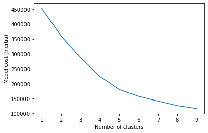

```python
plt.plot(k_range, inertia)
plt.xlabel('Number of clusters')
plt.ylabel('Model cost (Inertia)')
```

The most accurate number of clusters is not very clear. To determine the best value for k, the algorithm will be trained with 4, 5 and 6 clusters.

### Determination of the best number of clusters

#### Clustering With 6 clusters

##### K-Means clustering

```python
model_6 = KMeans(n_clusters=6, random_state=7)
# init = 'k-means ++' by default
model_6.fit(X)
y_pred_6 = model_6.predict(X)
```

##### Graphical representation

```
No handles with labels found to put in legend.
```

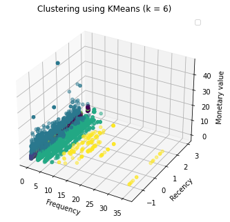

```python
# Interactive plot
# creating figure
fig = plt.figure()
ax = Axes3D(fig, auto_add_to_figure=False)
fig.add_axes(ax)
# creating the plot
plot_6_clusters = ax.scatter(X[:, 0], X[:, 1], X[:, 2],
                             c=y_pred_6, alpha=0.5, cmap='viridis')
# Recency [1]
# Frequency [0]
# Monetary (value) [2]
# Satisfaction [3]

# setting title and labels
ax.set_title('Clustering using KMeans (k = 6)')
ax.set_xlabel('Frequency')
ax.set_ylabel('Recency')
ax.set_zlabel('Monetary value')
plt.legend()
# displaying the plot
plt.show()
```

```
No handles with labels found to put in legend.
```

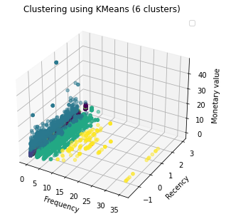

```python
fig = plt.figure(figsize=(5, 5))
ax = fig.add_subplot(111, projection='3d')
ax.scatter(X[:, 0], X[:, 1], X[:, 2], c=y_pred_6, alpha=0.5, cmap='viridis')
ax.scatter(model_6.cluster_centers_[:, 0],
           model_6.cluster_centers_[:, 1],
           model_6.cluster_centers_[:, 2], c='r')
ax.set_title('Clustering using KMeans (6 clusters)')
ax.set_xlabel('Frequency')
ax.set_ylabel('Recency')
ax.set_zlabel('Monetary value')
plt.legend()
plt.show()
```

##### Clusters information

```python
data_6 = data.copy()
data_6['label'] = model_6.labels_
```

```python
gb6 = data_6.groupby(model_6.labels_)
```

```python
gb6.size()
```

```
0    36601
1    47395
2     1922
3     7625
4    19516
5      151
dtype: int64
```

```python
gb6.mean()
```

|  | total_number_of_orders | days_since_order | total_payment_sum | review_score | label |
| --- | --- | --- | --- | --- | --- |
| 0 | 1.000000 | 1855.154121 | 150.558343 | 4.631786 | 0.0 |
| 1 | 1.000000 | 1583.063150 | 148.868629 | 4.674691 | 1.0 |
| 2 | 1.171176 | 1695.175858 | 1682.520125 | 3.694069 | 2.0 |
| 3 | 2.137705 | 1730.849967 | 304.782508 | 4.153443 | 3.0 |
| 4 | 1.000102 | 1694.662328 | 182.387405 | 1.623386 | 4.0 |
| 5 | 6.966887 | 1732.298013 | 841.236821 | 4.390728 | 5.0 |

##### Silhouette score

```python
from yellowbrick.cluster import SilhouetteVisualizer
```

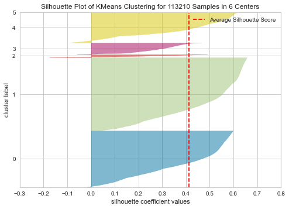

```python
visualizer_6 = SilhouetteVisualizer(model_6, colors='yellowbrick')

visualizer_6.fit(X)        # Fit the data to the visualizer
visualizer_6.show()        # Finalize and render the figure
```

##### Conclusion :

6 clusters seems not very appropriate (3 big clusters and 3 small with one < 200 customers) even though tendencies are appearing.

#### Clustering with 4 clusters

##### K-Means clustering

```python
model_4 = KMeans(n_clusters=4, random_state=7)
# init = 'k-means ++' by default
model_4.fit(X)
y_pred_4 = model_4.predict(X)
```

##### Graphical representation

```
No handles with labels found to put in legend.
```

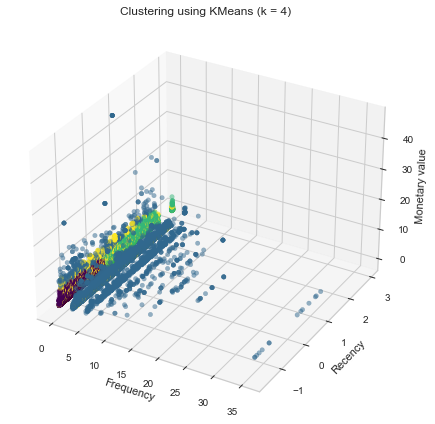

```python
# Interactive plot
# creating figure
fig = plt.figure()
ax = Axes3D(fig, auto_add_to_figure=False)
fig.add_axes(ax)
# creating the plot
plot_4_clusters = ax.scatter(X[:, 0], X[:, 1], X[:, 2],
                             c=y_pred_4, alpha=0.5, cmap='viridis')
# setting title and labels
ax.set_title('Clustering using KMeans (k = 4)')
ax.set_xlabel('Frequency')
ax.set_ylabel('Recency')
ax.set_zlabel('Monetary value')
plt.legend()
# displaying the plot
plt.show()
```

```
No handles with labels found to put in legend.
```

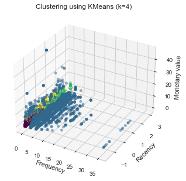

```python
fig = plt.figure(figsize=(5, 5))
ax = fig.add_subplot(111, projection='3d')
ax.scatter(X[:, 0], X[:, 1], X[:, 2], c=y_pred_4, alpha=0.5, cmap='viridis')
ax.scatter(model_4.cluster_centers_[:, 0],
           model_4.cluster_centers_[:, 1],
           model_4.cluster_centers_[:, 2], c='r')
ax.set_title('Clustering using KMeans (k=4)')
ax.set_xlabel('Frequency')
ax.set_ylabel('Recency')
ax.set_zlabel('Monetary value')
plt.legend()
plt.show()
```